# PA1_template.Rmd

Kyaw Thu

Monday, April 13, 2015

# **Loading and preprocessing the data**

```r
opts_chunk$set(echo=TRUE,results="asis")
cache=TRUE
```

```r
activity <- read.csv("activity.csv", header=TRUE)
activity$date = as.Date(activity$date, format="%Y-%m-%d")
names(activity)
```

```
## [1] "steps"    "date"     "interval"
```

# Remove all NA

```r
na_rm_activity<-activity[!is.na(activity$steps),]
```

**What is mean total number of steps taken per day**#

```r
Totalsteps <- tapply(na_rm_activity$steps, na_rm_activity$date, sum)
```

**Total number of steps taken per day and ignore NA value**

```r
Totalsteps<-Totalsteps[!is.na(Totalsteps)]
```

# Plotting histogram of total number of steps taken each day

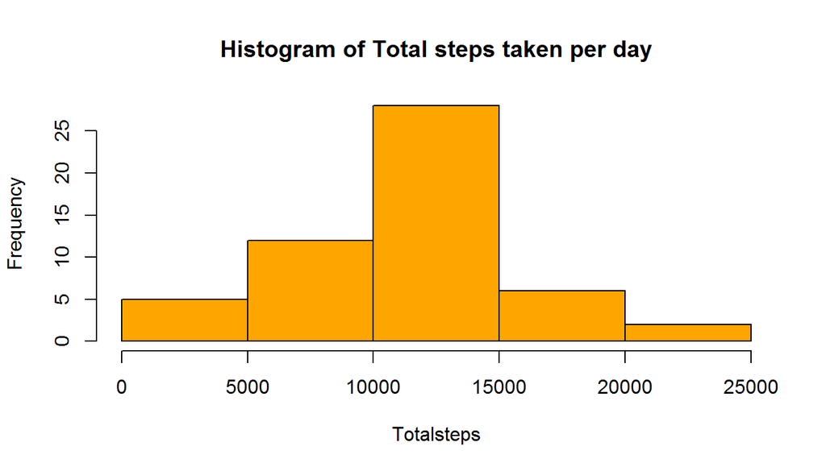

```r
hist(Totalsteps,col='orange',main="Histogram of Total steps taken per day")
```

# Mean and median of steps taken each day

```r
mean(Totalsteps)
```

```
## [1] 10766.19
```

```r
median(Totalsteps)
```

```
## [1] 10765
```

# **What is the average daily activity pattern?**

Average daily activity pattern can be analysed by timeseries function and produced its plot.

Daily activity pattern timeseries

```r
DailyPattern <- tapply(activity$steps, activity$interval, mean, na.rm = TRUE)
```

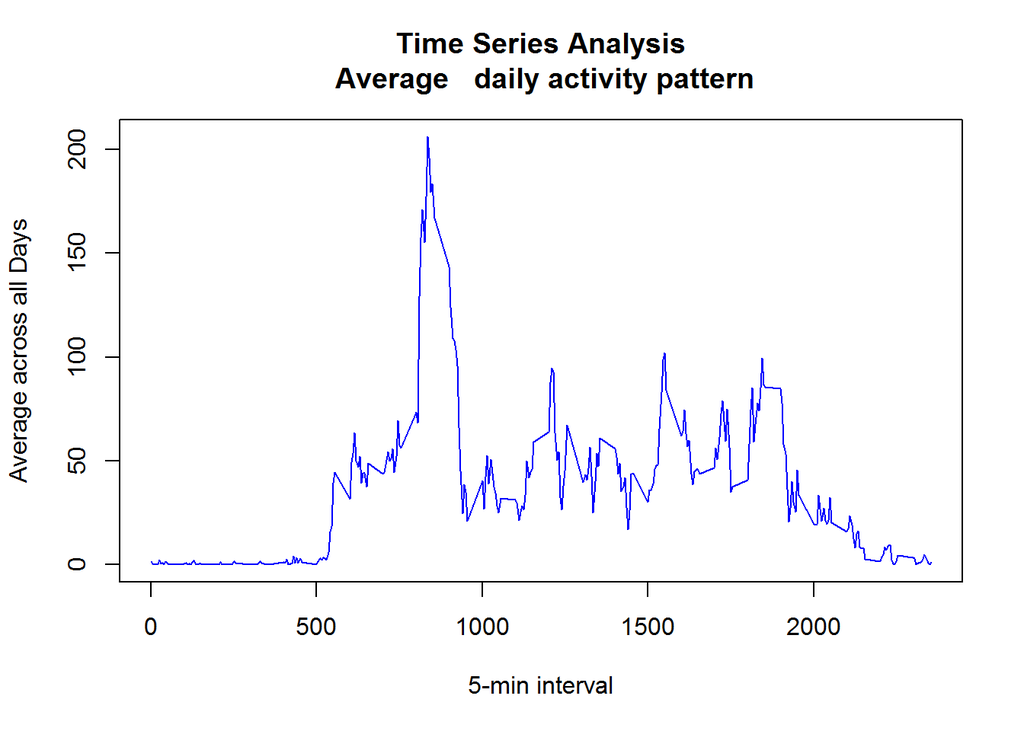

```r
plot(row.names(DailyPattern), DailyPattern, type = "l", xlab = "5-min interval", ylab = "Average across all Days", main = "Time Series Analysis\n Average   daily activity pattern", col = "blue")
```

**Maximum daily steps** 5-minute interval, on average across all the days in the dataset, contains the maximum number of steps 835.

5-minute interval, on average across all the days in the dataset, contains the maximum number of steps 835.

```r
which.max(DailyPattern)
```

```
## 835
## 104
```